# Exercise 1: Student Performance Visualization

Taliana Pirajan

2026-03-28

## Data

```r
library(ggplot2)

students <- data.frame(
  id = 1:20,
  hours_study = c(2,3,4,5,6,3,4,7,8,5,6,7,3,2,9,10,4,6,8,5),
  score = c(50,55,65,70,75,60,66,80,85,72,74,78,58,52,90,95,67,76,88,73),
  gender = rep(c("Male","Female"), 10),
  major = rep(c("Engineering","Business","Arts","Medicine"), 5)
)
```

## Scatter plot

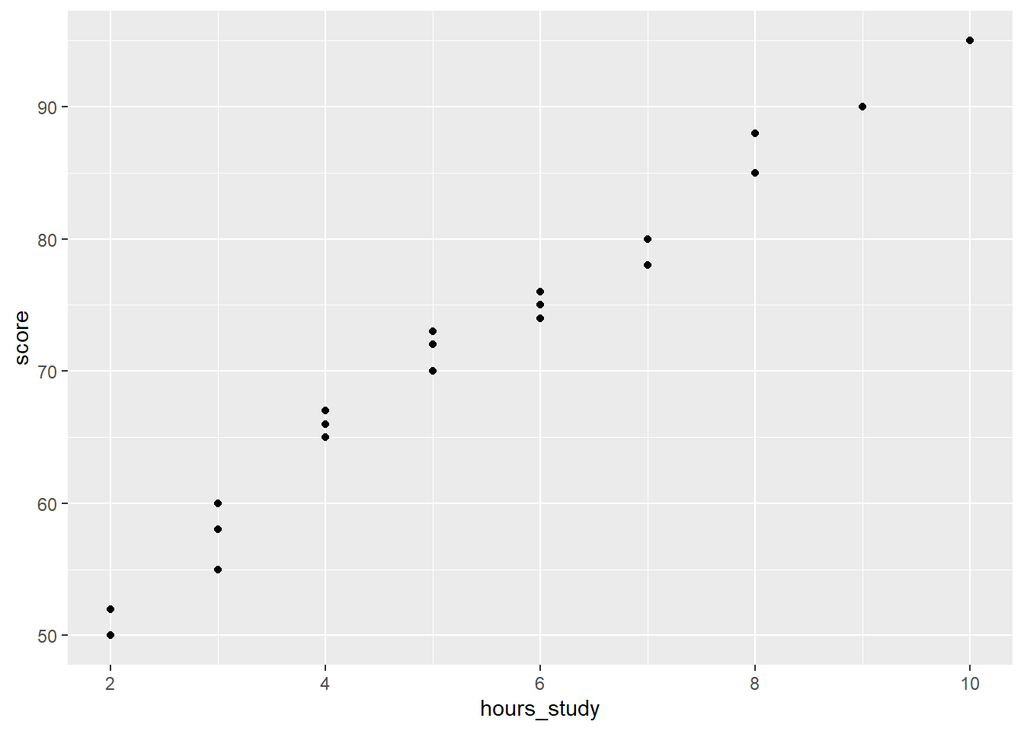

```r
ggplot(students, aes(x=hours_study, y=score)) + geom_point()
```

A medida que aumentan las horas de estudio, el puntaje tiende a subir, lo que muestra una relación positiva entre ambas variables.

## Blue points

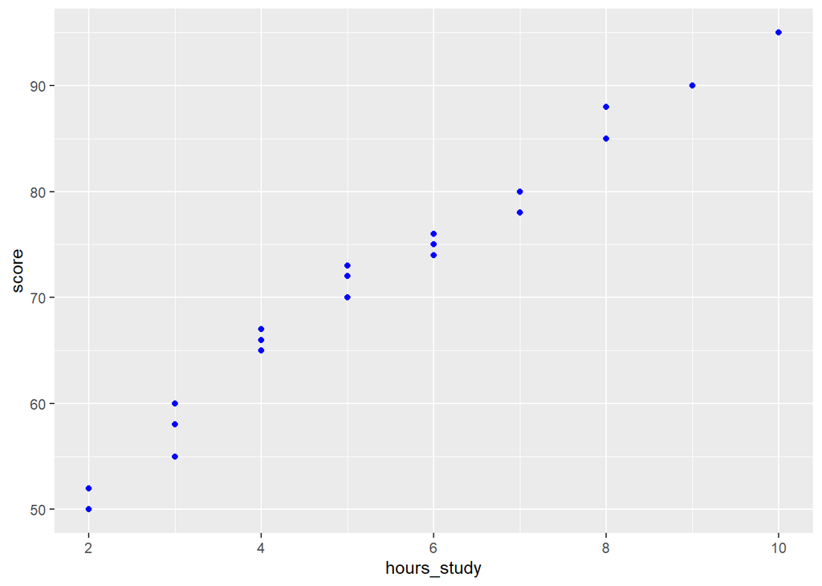

```r
ggplot(students, aes(x=hours_study, y=score)) + geom_point(color="blue")
```

El gráfico permite observar con claridad la relación positiva entre horas de estudio y puntaje.

## Gender color

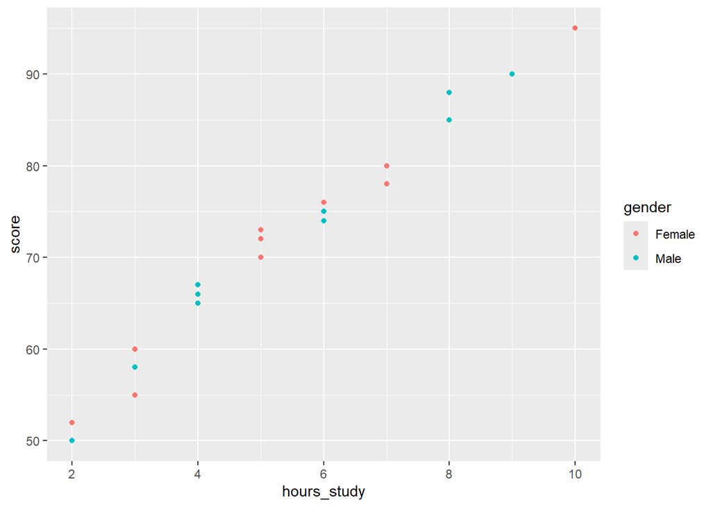

```r
ggplot(students, aes(x=hours_study, y=score, color=gender)) + geom_point()
```

Se observa que tanto hombres como mujeres siguen una tendencia similar en el rendimiento académico.

## Bigger points

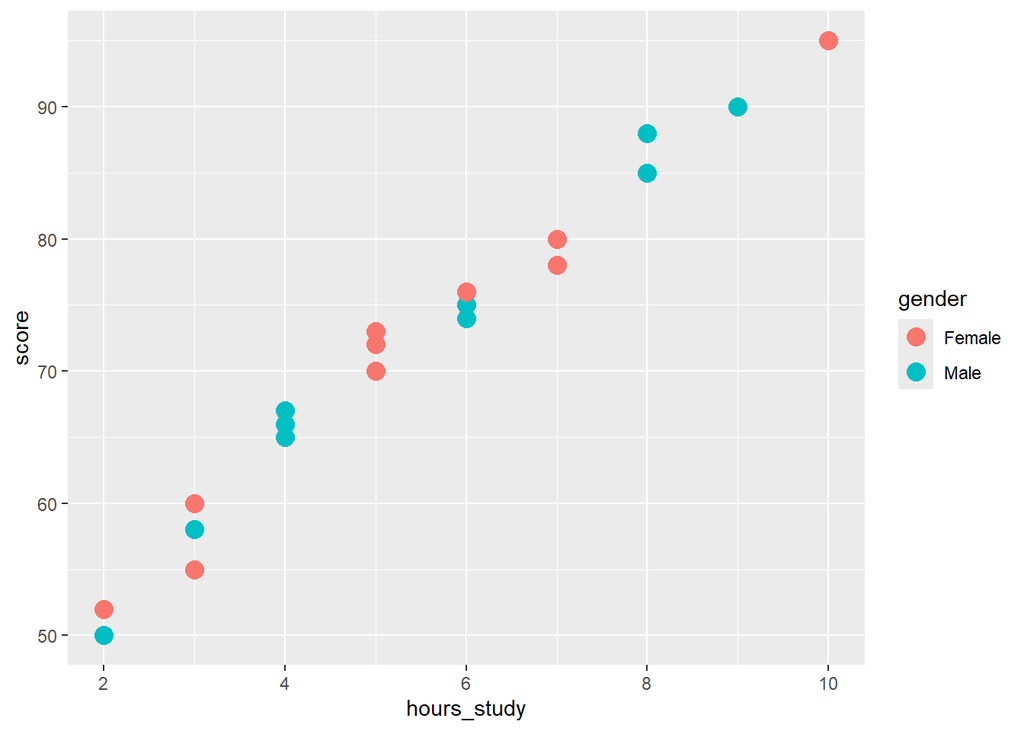

```r
ggplot(students, aes(x=hours_study, y=score, color=gender)) + geom_point(size=4)
```

El aumento en el tamaño de los puntos facilita identificar mejor la distribución de los datos.

## Title + labels + minimal theme

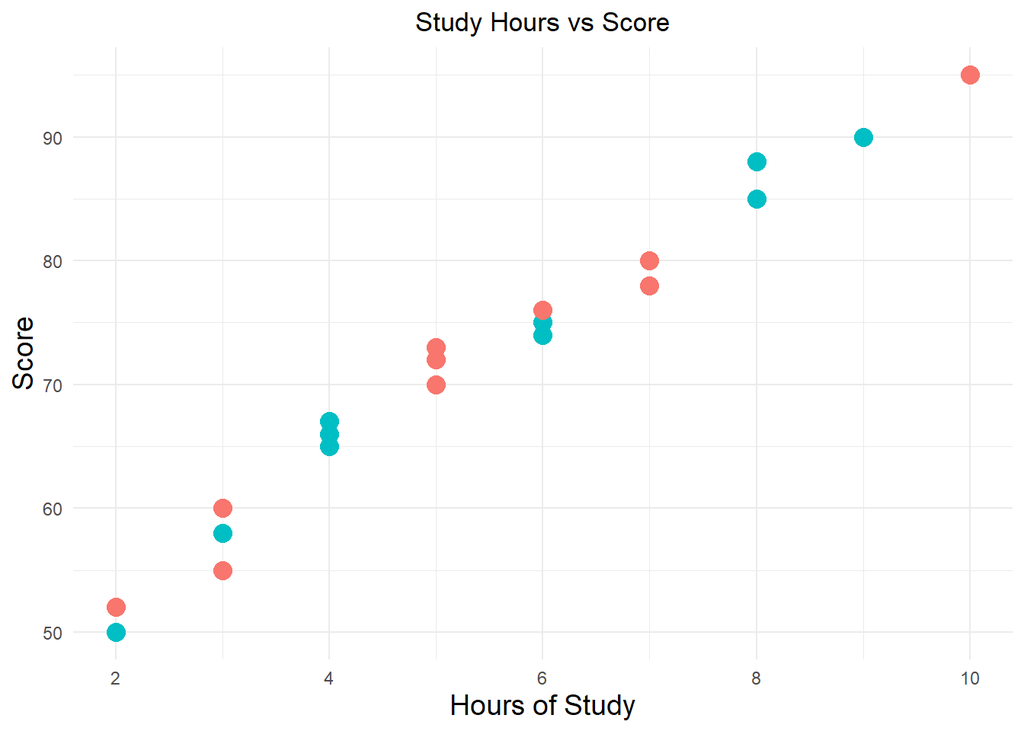

```r
ggplot(students, aes(x=hours_study, y=score, color=gender)) +
  geom_point(size=4) +
  labs(title="Study Hours vs Score", x="Hours of Study", y="Score") +
  theme_minimal() +
  theme(
    plot.title = element_text(hjust=0.5),
    axis.title = element_text(size=14),
    legend.position = "none"
  )
```

La presentación del gráfico permite ver de forma clara que al aumentar las horas de estudio también mejora el puntaje.

## Regression line

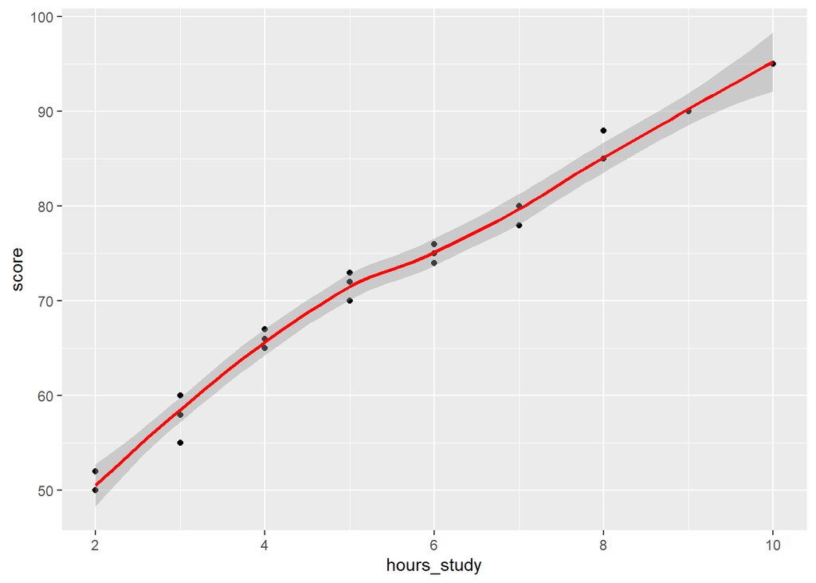

```r
ggplot(students, aes(x=hours_study, y=score)) +
  geom_point() +
  geom_smooth(color="red")
```

La línea de regresión confirma que existe una relación creciente entre las horas de estudio y el puntaje obtenido

## Boxplot

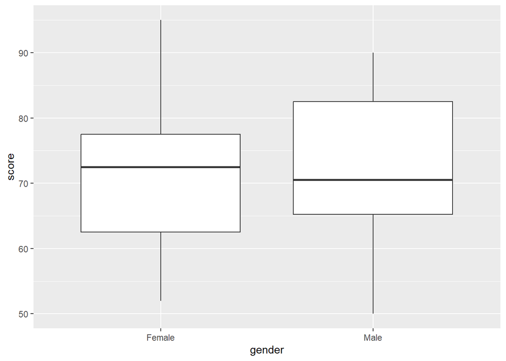

```r
ggplot(students, aes(x=gender, y=score)) + geom_boxplot()
```

Los puntajes presentan una distribución parecida entre ambos géneros, sin diferencias muy marcadas.

## Histogram

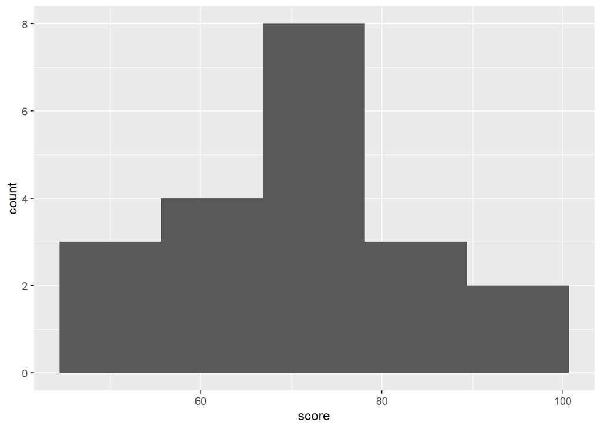

```r
ggplot(students, aes(x=score)) + geom_histogram(bins=5)
```

La mayoría de los puntajes se concentran en valores medios y altos.

## facet_wrap by major

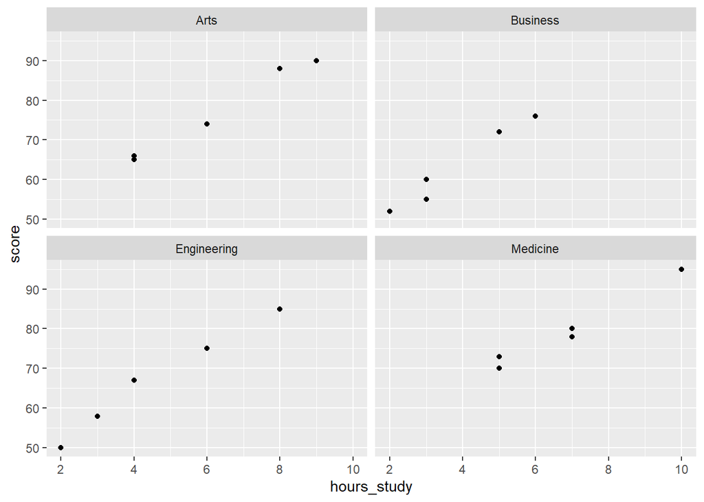

```r
ggplot(students, aes(x=hours_study, y=score)) +
  geom_point() +
  facet_wrap(~major)
```

Al separar por carrera se observa el comportamiento de cada grupo de estudiantes de forma individual

## facet_grid by gender and major

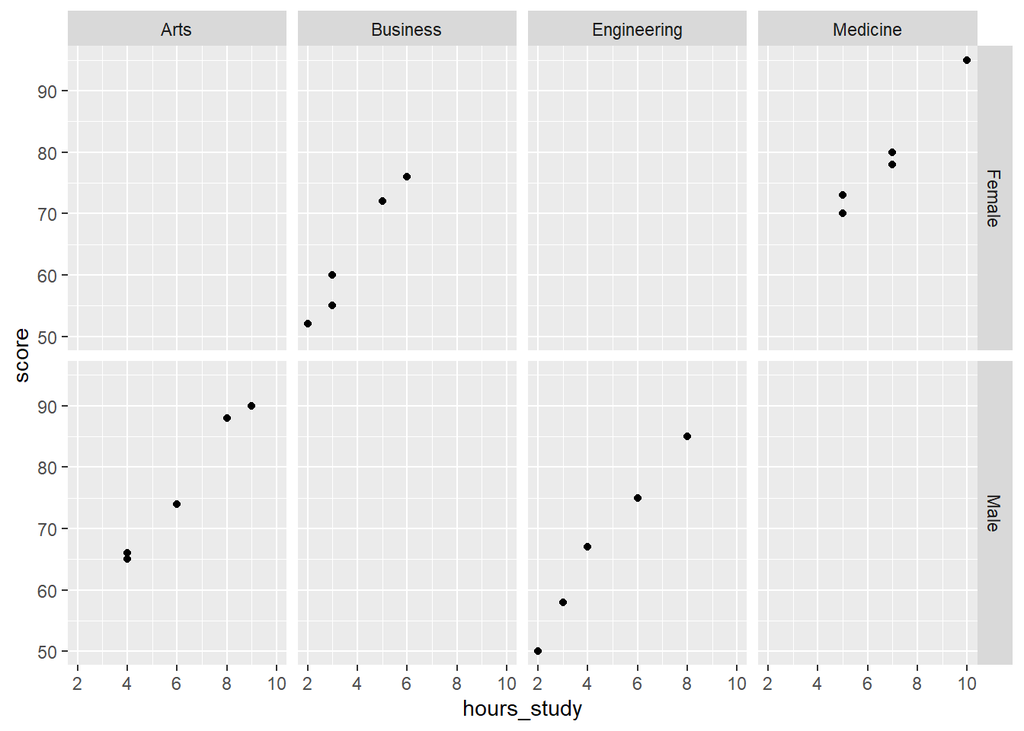

```r
ggplot(students, aes(x=hours_study, y=score)) +
  geom_point() +
  facet_grid(gender ~ major)
```

Cada carrera mantiene una tendencia positiva entre estudio y puntaje, aunque con pequeñas variaciones.

## Shape by major

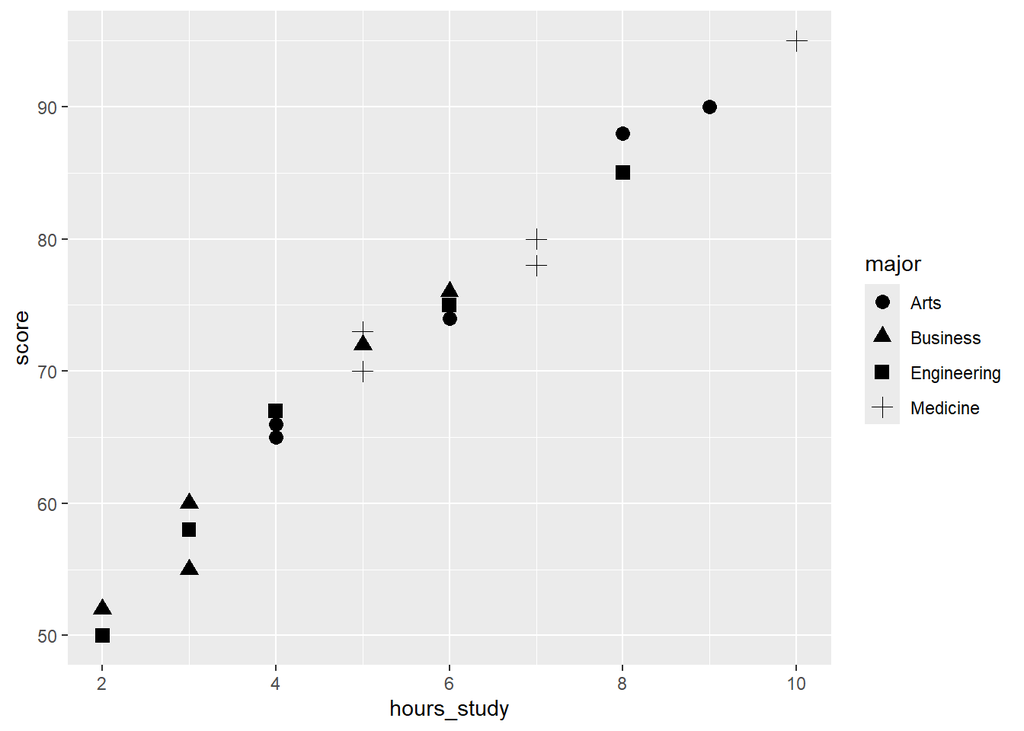

```r
ggplot(students, aes(x=hours_study, y=score, shape=major)) +
  geom_point(size=3)
```

La forma de los puntos permite diferenciar mejor cada carrera y comparar su comportamiento.

## Combined aesthetics

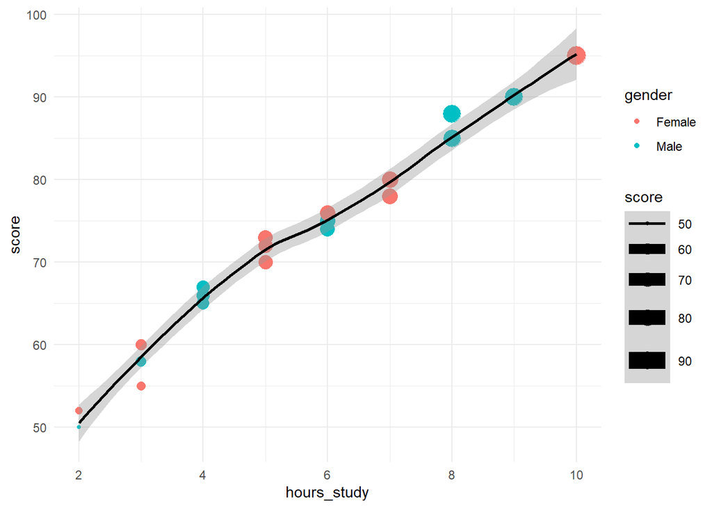

```r
ggplot(students, aes(x=hours_study, y=score, color=gender, size=score)) +
  geom_point() +
  geom_smooth(color="black") +
  theme_minimal()
```

Se observa que el puntaje aumenta junto con las horas de estudio y que el tamaño de los puntos resalta los valores más altos.

##“Punto 2: Exercise Business Data Visualization with ggplot2” Taliana Pirajan 2026-03-28

## Creación de la base de datos

```r
library(ggplot2)

sales <- data.frame(
  month = rep(month.abb[1:12], 4),
  region = rep(c("North","South","East","West"), each = 12),
  sales = c(
    120,130,125,140,150,160,170,165,155,145,135,125,
    100,110,105,120,130,135,140,138,132,125,118,110,
    90,95,100,110,115,120,125,123,118,112,105,98,
    80,85,88,95,100,105,110,108,102,97,90,85
  ),
  marketing_spend = c(
    20,22,21,23,25,26,28,27,26,24,23,22,
    18,19,18,20,22,23,24,23,22,21,20,19,
    15,16,17,18,19,20,21,20,19,18,17,16,
    12,13,14,15,16,17,18,17,16,15,14,13
  ),
  employees = rep(c(50,45,40,35), each = 12)
)
```

## Scatter plot of marketing_spend vs sales

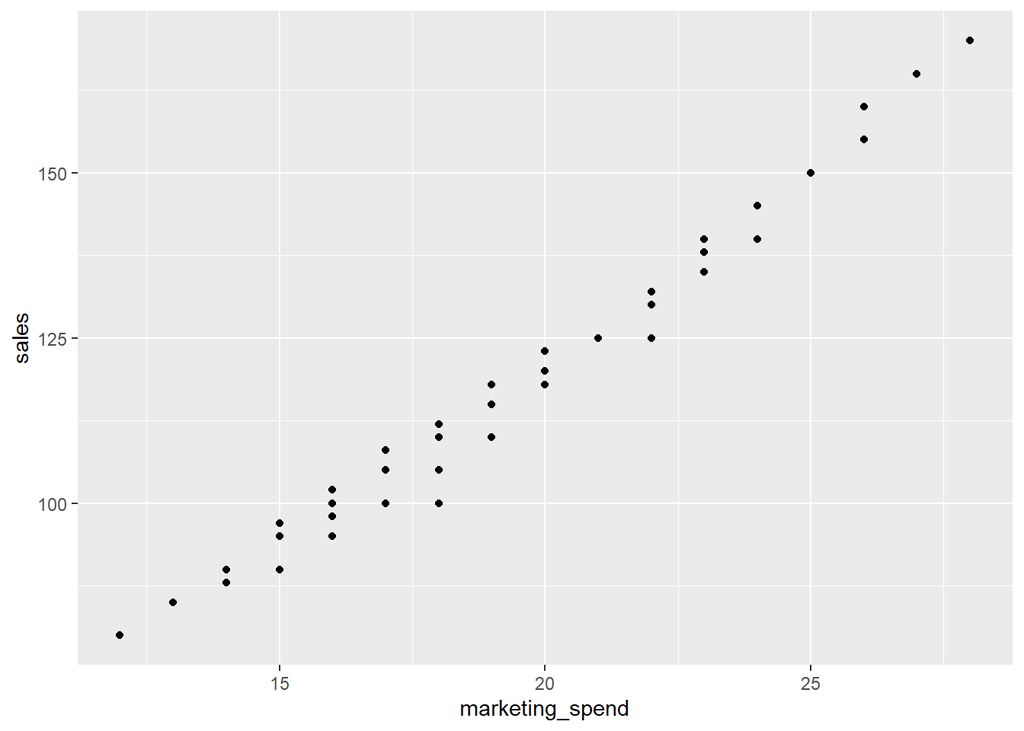

```r
ggplot(sales, aes(marketing_spend, sales)) +
  geom_point()
```

En este gráfico se observa de manera general cómo se relaciona la inversión en marketing con el nivel de ventas.

## Change point color to dark green

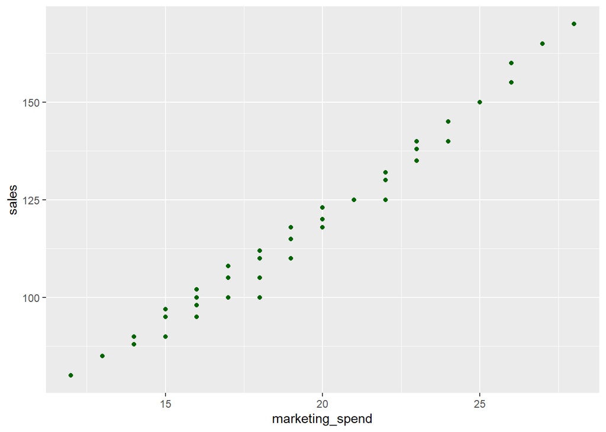

```r
ggplot(sales, aes(marketing_spend, sales)) +
  geom_point(color = "darkgreen")
```

El color verde facilita distinguir mejor cada observación.

## Map region to color

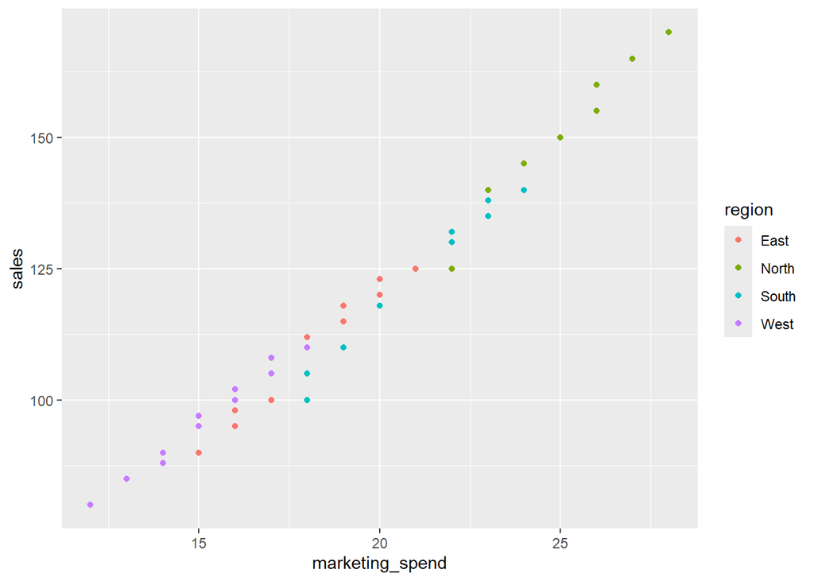

```r
ggplot(sales, aes(marketing_spend, sales, color = region)) +
  geom_point()
```

Cada región aparece diferenciada visualmente.

## Increase point size

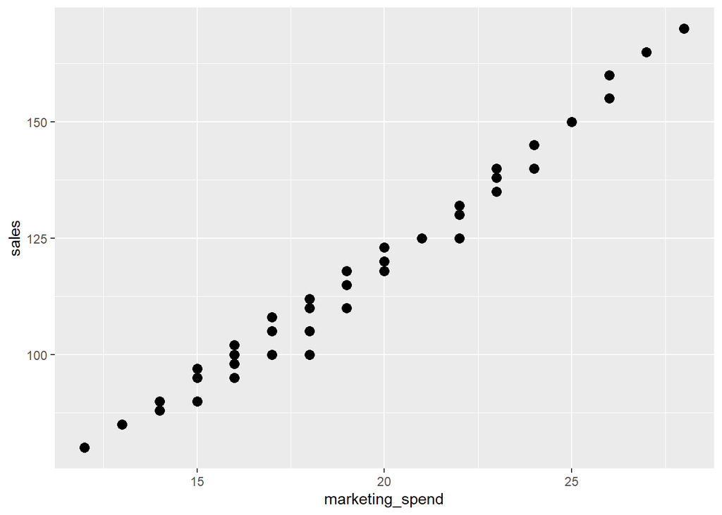

```r
ggplot(sales, aes(marketing_spend, sales)) +
  geom_point(size = 3)
```

El tamaño mejora la lectura de puntos.

## Add plot title

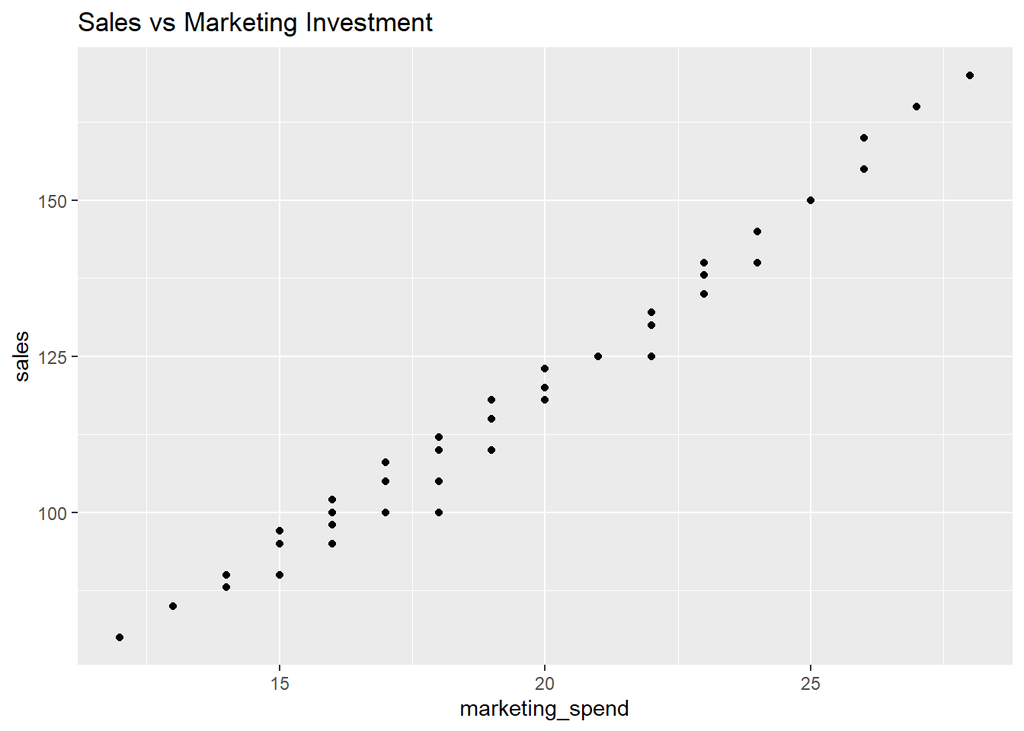

```r
ggplot(sales, aes(marketing_spend, sales)) +
  geom_point() +
  ggtitle("Sales vs Marketing Investment")
```

El título resume el análisis.

## Add axis labels

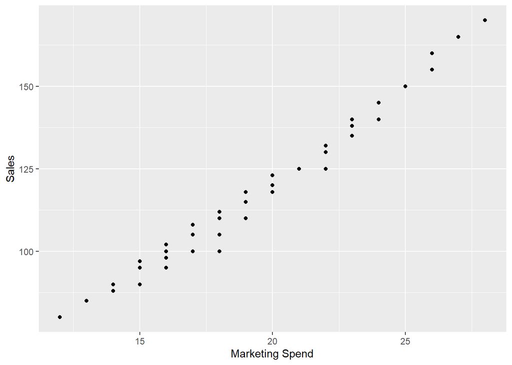

```r
ggplot(sales, aes(marketing_spend, sales)) +
  geom_point() +
  labs(x = "Marketing Spend", y = "Sales")
```

Las etiquetas aclaran el significado de variables.

## Use theme_minimal()

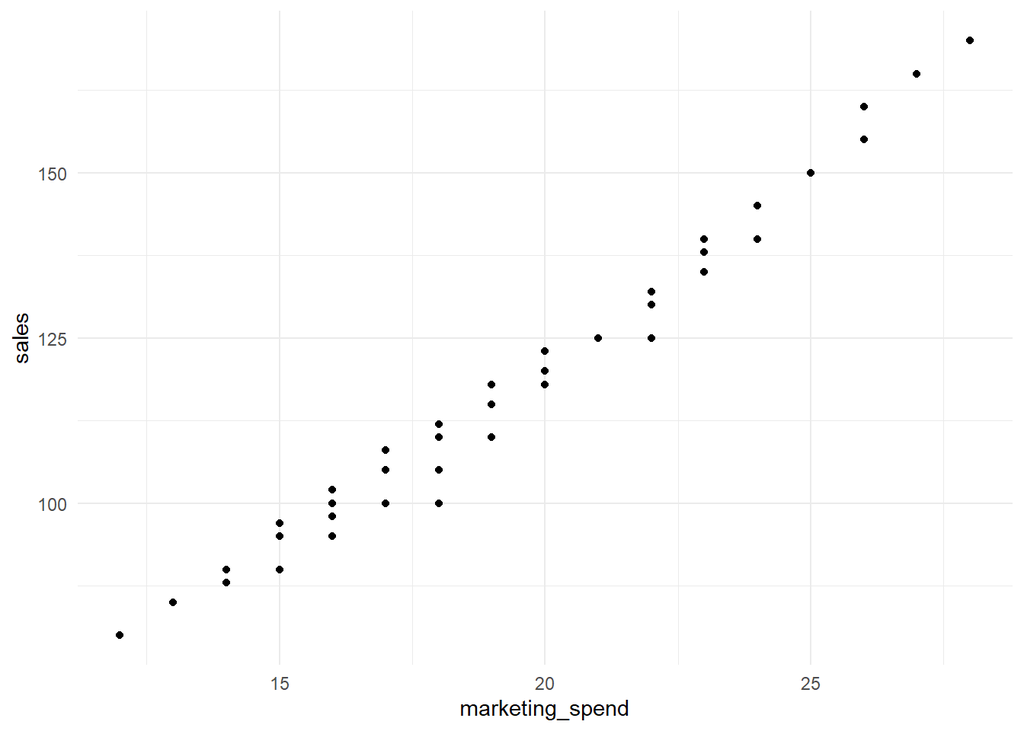

```r
ggplot(sales, aes(marketing_spend, sales)) +
  geom_point() +
  theme_minimal()
```

La presentación visual se vuelve más limpia.

## Center title

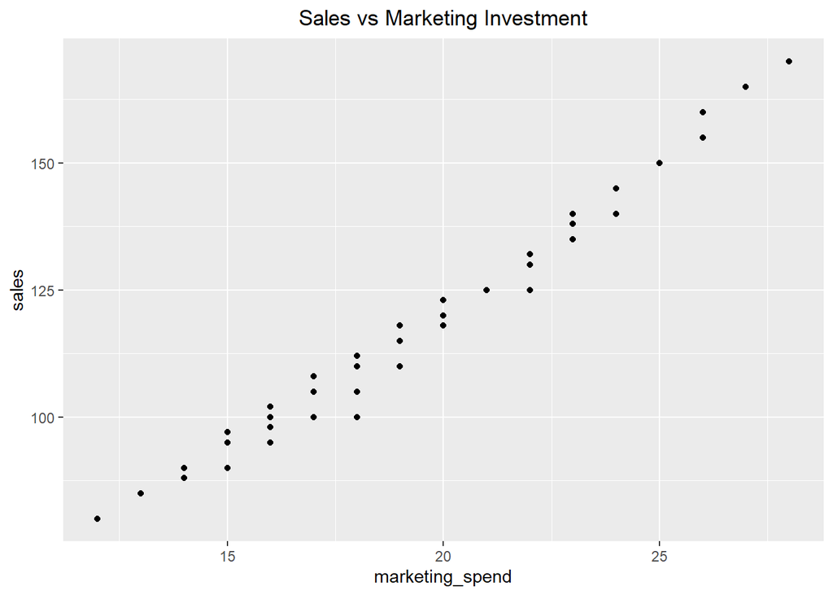

```r
ggplot(sales, aes(marketing_spend, sales)) +
  geom_point() +
  ggtitle("Sales vs Marketing Investment") +
  theme(plot.title = element_text(hjust = 0.5))
```

El título centrado mejora equilibrio visual.

## Change axis text size

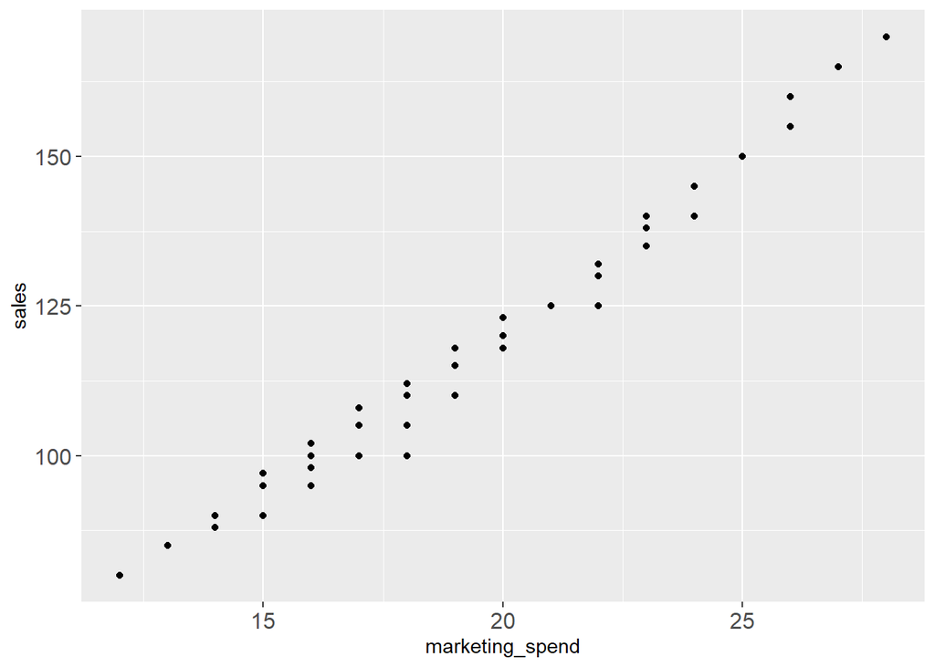

```r
ggplot(sales, aes(marketing_spend, sales)) +
  geom_point() +
  theme(axis.text = element_text(size = 12))
```

Facilita la lectura.

## Place legend at bottom

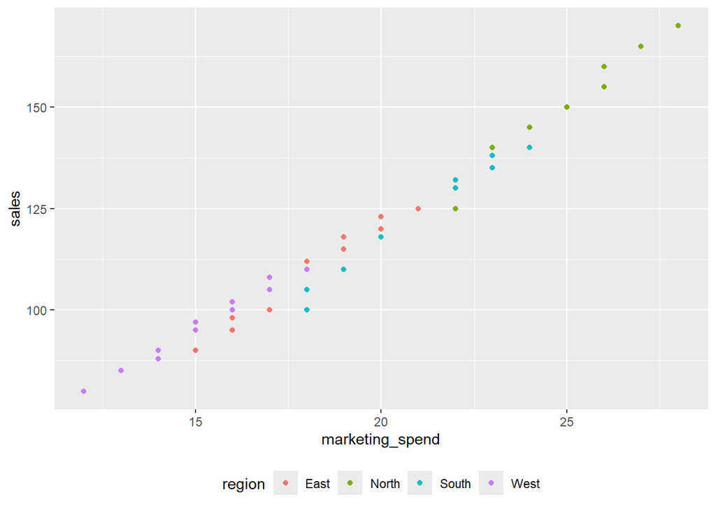

```r
ggplot(sales, aes(marketing_spend, sales, color = region)) +
  geom_point() +
  theme(legend.position = "bottom")
```

La leyenda se organiza mejor.

## Create line plot

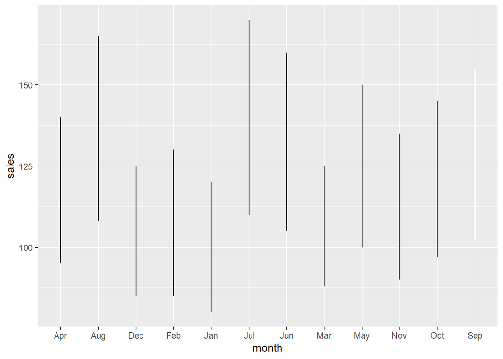

```r
ggplot(sales, aes(month, sales)) +
  geom_line()
```

## Map region to line color

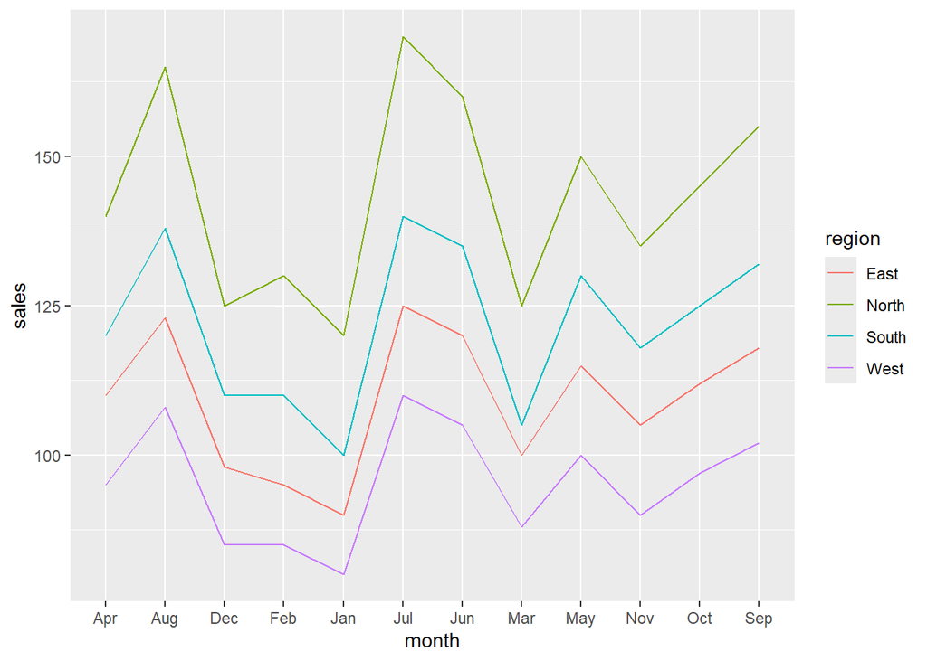

```r
ggplot(sales, aes(month, sales, color = region, group = region)) +
  geom_line()
```

Cada región muestra tendencia propia.

## Add points

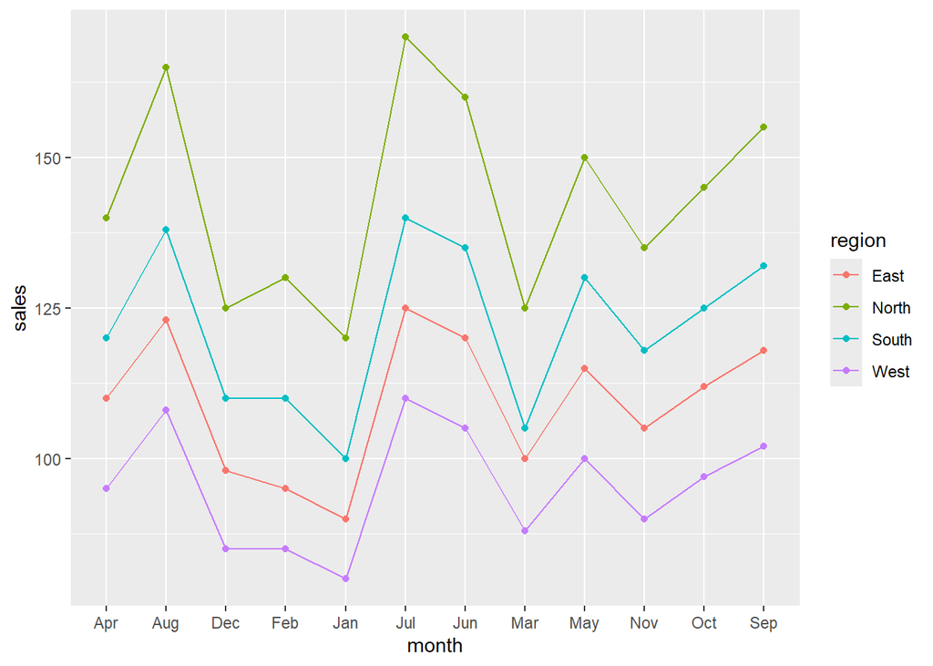

```r
ggplot(sales, aes(month, sales, color = region, group = region)) +
  geom_line() +
  geom_point()
```

Cada mes queda marcado visualmente.

## Rotate x-axis labels

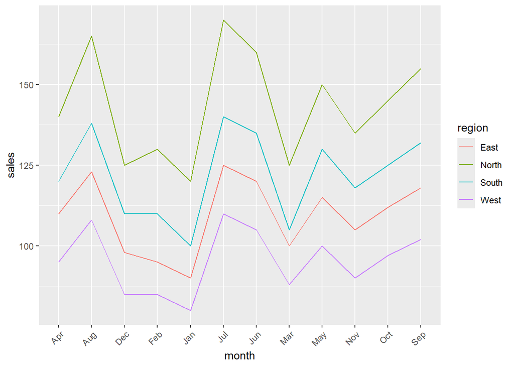

```r
ggplot(sales, aes(month, sales, color = region, group = region)) +
  geom_line() +
  theme(axis.text.x = element_text(angle = 45, hjust = 1))
```

Los meses se leen mejor.

## Highlight North region

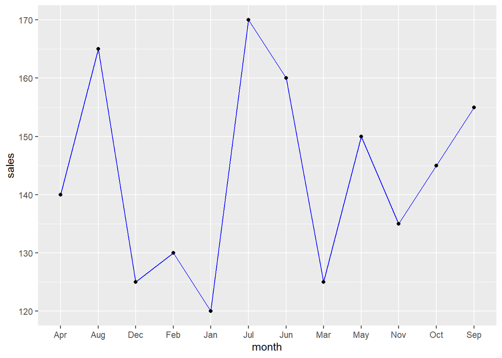

```r
ggplot(subset(sales, region == "North"), aes(month, sales, group = 1)) +
  geom_line(color = "blue") +
  geom_point()
```

Se analiza solo la región North.

## Boxplot of sales by region

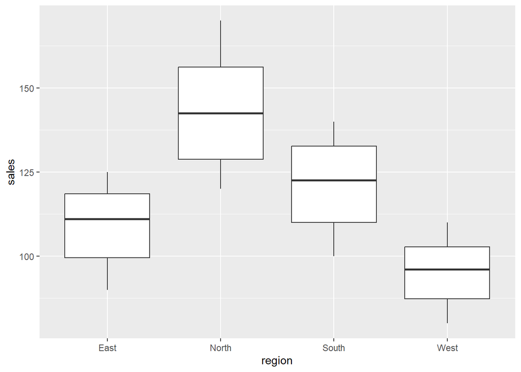

```r
ggplot(sales, aes(region, sales)) +
  geom_boxplot()
```

Permite comparar dispersión de ventas.

## Histogram of marketing_spend

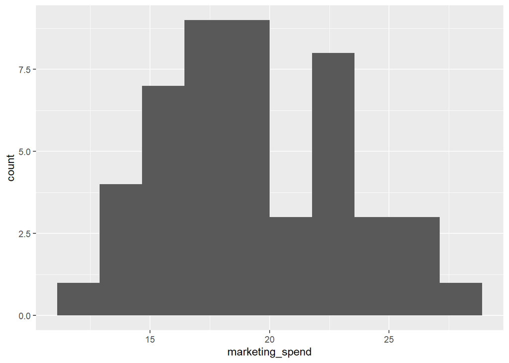

```r
ggplot(sales, aes(marketing_spend)) +
  geom_histogram(bins = 10)
```

Muestra frecuencia de inversión.

## Create line plots faceted by region

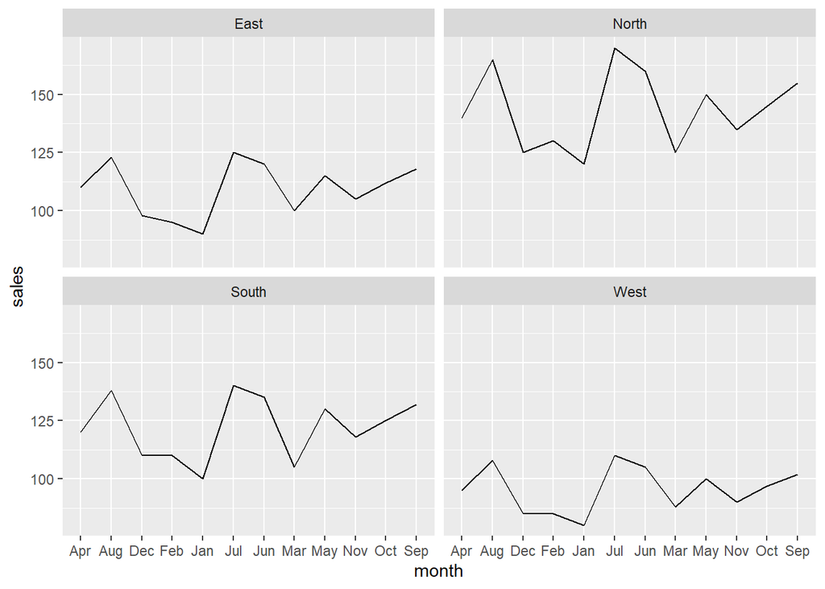

```r
ggplot(sales, aes(month, sales, group = 1)) +
  geom_line() +
  facet_wrap(~region)
```

Cada región aparece separada.

## Use facet_wrap()

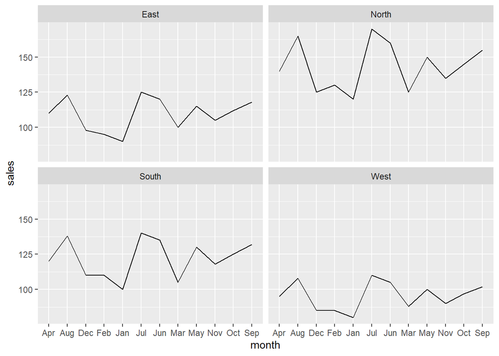

```r
ggplot(sales, aes(month, sales, group = 1)) +
  geom_line() +
  facet_wrap(~region)
```

Facilita comparación visual.

## Multi-aesthetic plot

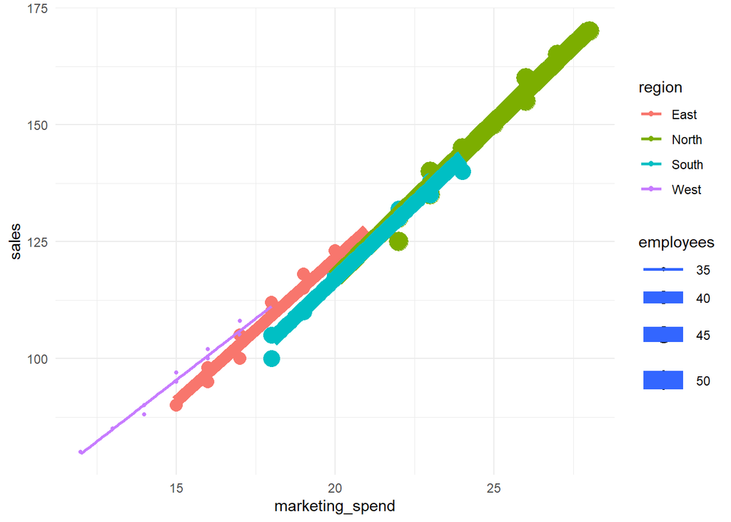

```r
ggplot(sales, aes(marketing_spend, sales,
                  color = region,
                  size = employees)) +
  geom_point() +
  geom_smooth(method = "lm", se = FALSE) +
  theme_minimal()
```

Integra varias variables en un solo análisis.

##“Punto 3: Exercises with Kaggle Dataset (Customer Churn)” Taliana Pirajan 2026-03-28

```r
library(ggplot2)

datos_churn <- data.frame(
  tenure = c(1,5,10,12,24,36,48,60,72,3,6,9,15,18,30,42,54,66,70,8),

  monthly_charges = c(
    70,75,80,85,90,95,100,105,110,65,
    72,78,82,88,92,98,102,108,112,76
  ),

  total_charges = c(
    70,375,800,1020,2160,3420,4800,6300,7920,195,
    432,702,1230,1584,2760,4116,5508,7128,7840,608
  ),

  churn = rep(c("Yes","No"), 10),

  contract = rep(
    c("Month-to-month","One year","Two year","Month-to-month"), 5
  ),

  internet_service = rep(
    c("DSL","Fiber optic","DSL","No"), 5
  )
)
```